# South Sudan Resilience

Let’s include measures from the locus of control, which is a sub-index of the aspirations index. These items are attitudinal statements:

- I can mostly determine what will happen in my life
- When I get what I want, it is usually because I worked hard for it
- My life is determined by my own actions

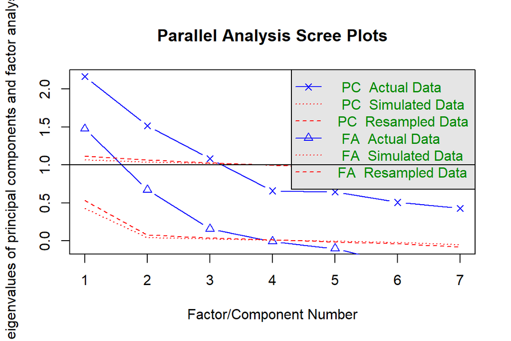

```
## Parallel analysis suggests that the number of factors =  3  and the number of components =  3
```

```r
dat %>%
  select(asp1:asp2,
         asp5:asp6,
         q_636:q_638) %>%
  fa.parallel(cor="mixed")
```

Three factors or components out of seven items, still not a good sign.

```r
asp3_alpha <- dat %>%
  select(asp1:asp2,
         asp5:asp6,
         q_636:q_638) %>%
  alpha()

asp3_alpha
```

```
##
## Reliability analysis
## Call: alpha(x = .)
##
##   raw_alpha std.alpha G6(smc) average_r S/N    ase mean   sd median_r
##       0.55       0.5    0.52      0.13   1 0.0081  2.4 0.52    0.086
##
##  lower alpha upper     95% confidence boundaries
## 0.54 0.55 0.57
##
##  Reliability if an item is dropped:
##       raw_alpha std.alpha G6(smc) average_r  S/N alpha se  var.r med.r
## asp1       0.55      0.48    0.50     0.135 0.94   0.0082 0.0271 0.073
## asp2       0.57      0.50    0.51     0.144 1.01   0.0080 0.0258 0.097
## asp5       0.55      0.47    0.48     0.127 0.87   0.0082 0.0284 0.053
## asp6       0.57      0.53    0.53     0.159 1.13   0.0081 0.0225 0.119
## q_636      0.45      0.44    0.45     0.117 0.80   0.0096 0.0152 0.097
## q_637      0.40      0.39    0.40     0.097 0.65   0.0105 0.0136 0.073
## q_638      0.37      0.40    0.39     0.101 0.67   0.0119 0.0096 0.086
##
##  Item statistics
##          n raw.r std.r r.cor r.drop mean   sd
## asp1  3541 0.262  0.46  0.27  0.150 0.78 0.41
## asp2  3540 0.183  0.42  0.21  0.070 0.80 0.40
## asp5  3531 0.249  0.49  0.32  0.157 0.84 0.37
## asp6  3477 0.098  0.36  0.12  0.022 0.92 0.28
## q_636 3540 0.754  0.54  0.44  0.426 4.01 1.62
## q_637 3542 0.737  0.62  0.58  0.505 4.91 1.26
## q_638 3539 0.789  0.61  0.58  0.537 4.71 1.46
##
## Non missing response frequency for each item
##          0    1    2    3    4    5    6 miss
## asp1  0.22 0.78 0.00 0.00 0.00 0.00 0.00 0.01
## asp2  0.20 0.80 0.00 0.00 0.00 0.00 0.00 0.01
## asp5  0.16 0.84 0.00 0.00 0.00 0.00 0.00 0.01
## asp6  0.08 0.92 0.00 0.00 0.00 0.00 0.00 0.02
## q_636 0.00 0.08 0.21 0.04 0.11 0.41 0.15 0.01
## q_637 0.00 0.03 0.06 0.02 0.08 0.44 0.35 0.01
## q_638 0.00 0.06 0.08 0.03 0.08 0.41 0.34 0.01
```

A reliability score of .55 is an improvement, but still does not reach the desired benchmark of .7.

```r
asp3_fa <- dat %>%
  select(asp1:asp2,
         asp5:asp6,
         q_636:q_638) %>%
  fa(cor="mixed")
```

```r
asp3_fa
```

```
## Factor Analysis using method =  minres
## Call: fa(r = ., cor = "mixed")
## Standardized loadings (pattern matrix) based upon correlation matrix
##        MR1    h2   u2 com
## asp1  0.31 0.097 0.90   1
## asp2  0.24 0.056 0.94   1
## asp5  0.36 0.128 0.87   1
## asp6  0.17 0.028 0.97   1
## q_636 0.54 0.287 0.71   1
## q_637 0.66 0.436 0.56   1
## q_638 0.67 0.444 0.56   1
##
##                 MR1
## SS loadings    1.47
## Proportion Var 0.21
##
## Mean item complexity =  1
## Test of the hypothesis that 1 factor is sufficient.
##
## The degrees of freedom for the null model are  21  and the objective function was  1.11 with Chi Square of  3958
## The degrees of freedom for the model are 14  and the objective function was  0.48
##
## The root mean square of the residuals (RMSR) is  0.13
## The df corrected root mean square of the residuals is  0.16
##
## The harmonic number of observations is  3518 with the empirical chi square  2642  with prob <  0
## The total number of observations was  3563  with Likelihood Chi Square =  1692  with prob <  0
##
## Tucker Lewis Index of factoring reliability =  0.36
## RMSEA index =  0.183  and the 90 % confidence intervals are  0.176 0.191
## BIC =  1578
## Fit based upon off diagonal values = 0.69
## Measures of factor score adequacy
##                                                    MR1
## Correlation of (regression) scores with factors   0.83
## Multiple R square of scores with factors          0.70
## Minimum correlation of possible factor scores     0.39
```

Let’s try just the three locus of control items.

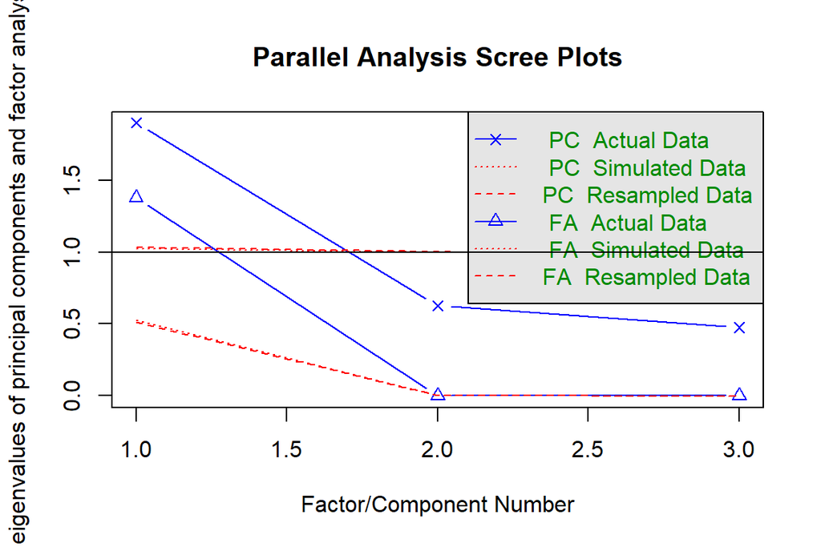

```
## Parallel analysis suggests that the number of factors =  1  and the number of components =  1
```

```r
dat %>%
  select(q_636:q_638) %>%
  fa.parallel(cor="poly")
```

One factor or component, that’s hopeful.

```r
asp4_alpha <- dat %>%
  select(q_636:q_638) %>%
  alpha()

asp4_alpha
```

```
##
## Reliability analysis
## Call: alpha(x = .)
##
##   raw_alpha std.alpha G6(smc) average_r S/N    ase mean  sd median_r
##       0.68      0.69     0.6      0.43 2.2 0.0091  4.5 1.1     0.43
##
##  lower alpha upper     95% confidence boundaries
## 0.67 0.68 0.7
##
##  Reliability if an item is dropped:
##       raw_alpha std.alpha G6(smc) average_r S/N alpha se var.r med.r
## q_636      0.66      0.66    0.50      0.50 2.0    0.011    NA  0.50
## q_637      0.60      0.60    0.43      0.43 1.5    0.013    NA  0.43
## q_638      0.51      0.52    0.35      0.35 1.1    0.016    NA  0.35
##
##  Item statistics
##          n raw.r std.r r.cor r.drop mean  sd
## q_636 3540  0.79  0.76  0.54   0.46  4.0 1.6
## q_637 3542  0.75  0.78  0.61   0.50  4.9 1.3
## q_638 3539  0.82  0.82  0.68   0.56  4.7 1.5
##
## Non missing response frequency for each item
##          1    2    3    4    5    6 miss
## q_636 0.08 0.21 0.04 0.11 0.41 0.15 0.01
## q_637 0.03 0.06 0.02 0.08 0.44 0.35 0.01
## q_638 0.06 0.08 0.03 0.08 0.41 0.34 0.01
```

Reliability of .68, that’s good enough for an index.

```r
asp4_fa <- dat %>%
  select(q_636:q_638) %>%
  fa(cor="poly")

asp4_fa
```

```
## Factor Analysis using method =  minres
## Call: fa(r = ., cor = "poly")
## Standardized loadings (pattern matrix) based upon correlation matrix
##        MR1   h2   u2 com
## q_636 0.60 0.35 0.65   1
## q_637 0.63 0.40 0.60   1
## q_638 0.79 0.62 0.38   1
##
##                 MR1
## SS loadings    1.38
## Proportion Var 0.46
##
## Mean item complexity =  1
## Test of the hypothesis that 1 factor is sufficient.
##
## The degrees of freedom for the null model are  3  and the objective function was  0.57 with Chi Square of  2027
## The degrees of freedom for the model are 0  and the objective function was  0
##
## The root mean square of the residuals (RMSR) is  0
## The df corrected root mean square of the residuals is  NA
##
## The harmonic number of observations is  3538 with the empirical chi square  0  with prob <  NA
## The total number of observations was  3563  with Likelihood Chi Square =  0  with prob <  NA
##
## Tucker Lewis Index of factoring reliability =  -Inf
## Fit based upon off diagonal values = 1
## Measures of factor score adequacy
##                                                    MR1
## Correlation of (regression) scores with factors   0.86
## Multiple R square of scores with factors          0.74
## Minimum correlation of possible factor scores     0.48
```

```r
library(effectsize)
interpret_nnfi(asp4_fa)
```

[output not shown]

I’m not sure how to interpret the fit scores, but I think we can generate an index out of these three items. Let’s impute missing values and generate the index.

## 4.2 Impute missing values

```r
locus <- dat %>%
  select(county,
         hhsize=household_members,
         q_636:q_638) %>%
  as.data.frame() %>%
  mutate(County = factor(county)) %>%
  select(-county)

locus[,1:4] <- lapply(locus[,1:4], as.numeric)
#str(locus)
```

```r
locus_imp <- missForest(locus)
```

```
##   missForest iteration 1 in progress...done!
##   missForest iteration 2 in progress...done!
##   missForest iteration 3 in progress...done!
##   missForest iteration 4 in progress...done!
```

```r
locus_imp$OOBerror
```

```
## NRMSE   PFC
## 0.762 0.000
```

```r
locus_out <- locus_imp$ximp
```

Compare means for raw and imputed variables

```r
describe(locus)
```

| vars | n | mean | sd | median | trimmed | mad | min | max | range | skew | kurtosis | se |
| --- | --- | --- | --- | --- | --- | --- | --- | --- | --- | --- | --- | --- |
| 1 | 3.55e+03 | 4.97 | 2.86 | 5 | 4.78 | 2.97 | 1 | 23 | 22 | 0.707 | 1.51 | 0.048 |
| 2 | 3.54e+03 | 4.01 | 1.62 | 5 | 4.12 | 1.48 | 1 | 6 | 5 | -0.557 | -1.12 | 0.0272 |
| 3 | 3.54e+03 | 4.91 | 1.26 | 5 | 5.17 | 1.48 | 1 | 6 | 5 | -1.59 | 2.03 | 0.0211 |
| 4 | 3.54e+03 | 4.71 | 1.46 | 5 | 4.96 | 1.48 | 1 | 6 | 5 | -1.3 | 0.652 | 0.0246 |
| 5 | 3.56e+03 | 3.48 | 1.73 | 4 | 3.48 | 2.97 | 1 | 6 | 5 | 0.00988 | -1.3 | 0.029 |

```r
describe(locus_out)
```

| vars | n | mean | sd | median | trimmed | mad | min | max | range | skew | kurtosis | se |
| --- | --- | --- | --- | --- | --- | --- | --- | --- | --- | --- | --- | --- |
| 1 | 3.56e+03 | 4.97 | 2.85 | 5 | 4.78 | 2.97 | 1 | 23 | 22 | 0.706 | 1.51 | 0.0478 |
| 2 | 3.56e+03 | 4.02 | 1.61 | 5 | 4.12 | 1.48 | 1 | 6 | 5 | -0.561 | -1.11 | 0.027 |
| 3 | 3.56e+03 | 4.91 | 1.25 | 5 | 5.17 | 1.48 | 1 | 6 | 5 | -1.59 | 2.06 | 0.021 |
| 4 | 3.56e+03 | 4.71 | 1.46 | 5 | 4.96 | 1.48 | 1 | 6 | 5 | -1.31 | 0.667 | 0.0244 |
| 5 | 3.56e+03 | 3.48 | 1.73 | 4 | 3.48 | 2.97 | 1 | 6 | 5 | 0.00988 | -1.3 | 0.029 |

```r
a <- locus %>%
  mutate(id=1:3563) %>%
  filter(is.na(hhsize) |
           is.na(q_636) |
           is.na(q_637) |
           is.na(q_638))

a_id <- a$id

a[1:6,]
```

| hhsize | q_636 | q_637 | q_638 | County | id |
| --- | --- | --- | --- | --- | --- |
|  | 6 | 4 | 2 | Akobo | 107 |
| 5 |  | 6 | 6 | Duk | 325 |
| 4 |  |  |  | Duk | 342 |
|  | 6 | 6 | 6 | Duk | 376 |
| 7 | 5 | 6 |  | Duk | 425 |
|  | 6 | 6 | 6 | Duk | 510 |

```r
b <- locus_out %>%
  mutate(id=1:3563) %>%
  filter(id %in% a_id)

b[1:6,]
```

| hhsize | q_636 | q_637 | q_638 | County | id |
| --- | --- | --- | --- | --- | --- |
| 5.13 | 6 | 4 | 2 | Akobo | 107 |
| 5 | 5.53 | 6 | 6 | Duk | 325 |
| 4 | 4.91 | 5.11 | 5.3 | Duk | 342 |
| 5.96 | 6 | 6 | 6 | Duk | 376 |
| 7 | 5 | 6 | 5.53 | Duk | 425 |
| 5.96 | 6 | 6 | 6 | Duk | 510 |

Now generate the index

```r
loc_fa <- locus_out %>%
  select(2:4) %>%
  fa(cor="poly")
loc_fa
```

```
## Factor Analysis using method =  minres
## Call: fa(r = ., cor = "poly")
## Standardized loadings (pattern matrix) based upon correlation matrix
##        MR1   h2   u2 com
## q_636 0.59 0.34 0.66   1
## q_637 0.63 0.39 0.61   1
## q_638 0.79 0.62 0.38   1
##
##                 MR1
## SS loadings    1.36
## Proportion Var 0.45
##
## Mean item complexity =  1
## Test of the hypothesis that 1 factor is sufficient.
##
## The degrees of freedom for the null model are  3  and the objective function was  0.56 with Chi Square of  1977
## The degrees of freedom for the model are 0  and the objective function was  0
##
## The root mean square of the residuals (RMSR) is  0
## The df corrected root mean square of the residuals is  NA
##
## The harmonic number of observations is  3563 with the empirical chi square  0  with prob <  NA
## The total number of observations was  3563  with Likelihood Chi Square =  0  with prob <  NA
##
## Tucker Lewis Index of factoring reliability =  -Inf
## Fit based upon off diagonal values = 1
## Measures of factor score adequacy
##                                                    MR1
## Correlation of (regression) scores with factors   0.86
## Multiple R square of scores with factors          0.74
## Minimum correlation of possible factor scores     0.48
```

Compare to the non-imputed loadings

```r
asp4_fa
```

```
## Factor Analysis using method =  minres
## Call: fa(r = ., cor = "poly")
## Standardized loadings (pattern matrix) based upon correlation matrix
##        MR1   h2   u2 com
## q_636 0.60 0.35 0.65   1
## q_637 0.63 0.40 0.60   1
## q_638 0.79 0.62 0.38   1
##
##                 MR1
## SS loadings    1.38
## Proportion Var 0.46
##
## Mean item complexity =  1
## Test of the hypothesis that 1 factor is sufficient.
##
## The degrees of freedom for the null model are  3  and the objective function was  0.57 with Chi Square of  2027
## The degrees of freedom for the model are 0  and the objective function was  0
##
## The root mean square of the residuals (RMSR) is  0
## The df corrected root mean square of the residuals is  NA
##
## The harmonic number of observations is  3538 with the empirical chi square  0  with prob <  NA
## The total number of observations was  3563  with Likelihood Chi Square =  0  with prob <  NA
##
## Tucker Lewis Index of factoring reliability =  -Inf
## Fit based upon off diagonal values = 1
## Measures of factor score adequacy
##                                                    MR1
## Correlation of (regression) scores with factors   0.86
## Multiple R square of scores with factors          0.74
## Minimum correlation of possible factor scores     0.48
```

The loading for q_636 goes down a tad, but otherwise ok

```r
dat <- dat %>%
  mutate(Locus = loc_fa$scores)

describe(dat$Locus)
```

| vars | n | mean | sd | median | trimmed | mad | min | max | range | skew | kurtosis | se |
| --- | --- | --- | --- | --- | --- | --- | --- | --- | --- | --- | --- | --- |
| 1 | 3.56e+03 | -2.51e-16 | 0.865 | 0.283 | 0.125 | 0.557 | -2.7 | 1.03 | 3.73 | -1.28 | 1.1 | 0.0145 |

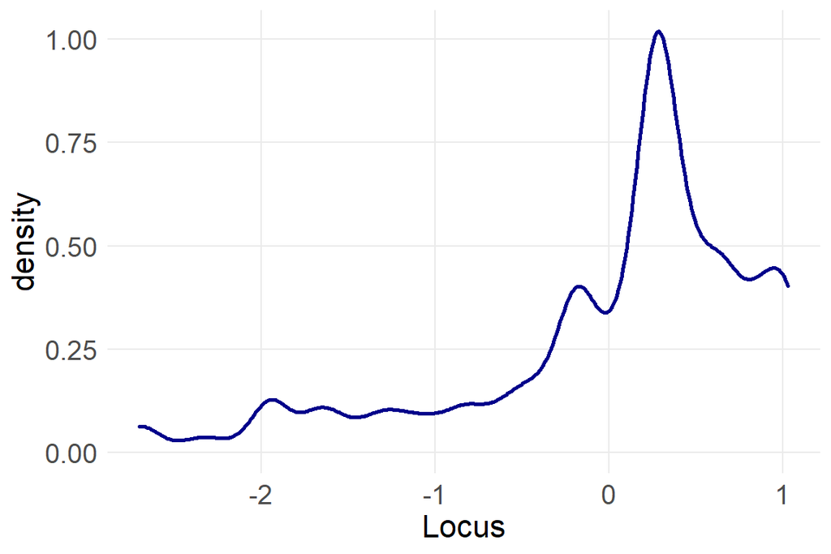

```r
ggplot(dat, aes(Locus)) +
  geom_density(size=1, color="darkblue")
```

## 4.3 Compare output

By county

```r
loc_cnty <- dat %>%
  group_by(county) %>%
  summarize(loc = mean(Locus, na.rm=T),
            se = std.error(Locus),
            q638=mean(q_638, na.rm=T),
            se2 = std.error(q_638, na.rm=T)) %>%
  mutate(lower=loc-1.96*se,
         upper=loc+1.96*se,
         lower2 = q638-1.96*se2,
         upper2 = q638+1.96*se2)

loc_cnty
```

| county | loc | se | q638 | se2 | lower | upper | lower2 | upper2 |
| --- | --- | --- | --- | --- | --- | --- | --- | --- |
| Akobo | -0.157 | 0.039 | 4.29 | 0.0683 | -0.233 | -0.0802 | 4.16 | 4.43 |
| Budi | -0.00318 | 0.0317 | 4.83 | 0.0478 | -0.0653 | 0.0589 | 4.74 | 4.93 |
| Duk | 0.492 | 0.021 | 5.4 | 0.0353 | 0.45 | 0.533 | 5.33 | 5.47 |
| Leer | -0.209 | 0.0369 | 4.29 | 0.0712 | -0.281 | -0.136 | 4.15 | 4.43 |
| Pibor | 0.351 | 0.0155 | 5.24 | 0.0251 | 0.321 | 0.382 | 5.19 | 5.29 |
| Uror | -0.363 | 0.0414 | 4.39 | 0.0687 | -0.444 | -0.281 | 4.25 | 4.52 |

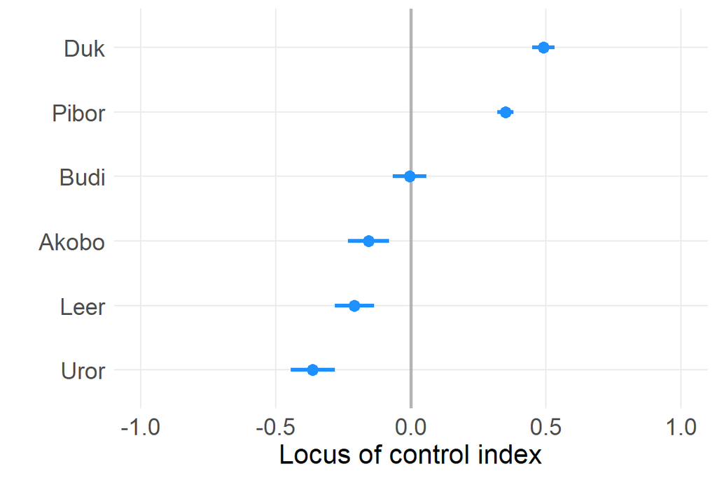

```r
ggplot(loc_cnty, aes(loc, fct_reorder(county, loc))) +
  geom_vline(xintercept=0, size=1, alpha=.7, color="grey60") +
#  geom_vline(xintercept=4, size=1, alpha=.7, color="aquamarine3") +
  geom_point(color="dodgerblue", size=3) +
  geom_errorbar(aes(xmin=lower, xmax=upper),
                color="dodgerblue",
                width=0,
                size=1.1) +
  scale_x_continuous(limits=c(-1,1),
                     breaks=seq(-1,1,.5)) +
  labs(x="Locus of control index",
       y="")
```

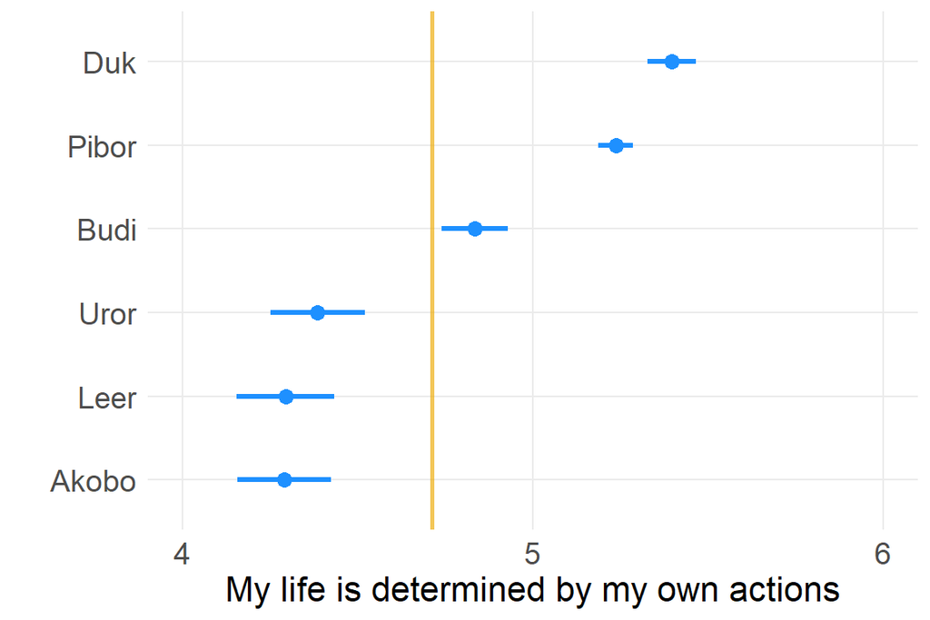

```r
ggplot(loc_cnty, aes(q638, fct_reorder(county, q638))) +
  geom_vline(xintercept=mean(dat$q_638, na.rm=T), size=1, alpha=.7, color="darkgoldenrod2") +
  #geom_vline(xintercept=4, size=1, alpha=.7, color="aquamarine3") +
  geom_point(color="dodgerblue", size=3) +
  geom_errorbar(aes(xmin=lower2, xmax=upper2),
                color="dodgerblue",
                width=0,
                size=1.1) +
  scale_x_continuous(limits=c(4,6),
                     breaks=4:6) +
  labs(x="My life is determined by my own actions",
       y="")
```

```r
loc_cnty_wt <- svyrdat %>%
  group_by(county) %>%
  summarize(loc = survey_mean(Locus, na.rm=T)) %>%
  mutate(lower=loc-1.96*loc_se,
         upper=loc+1.96*loc_se)
```

[output not shown]

```r
loc_cnty_wt
```

[output not shown]

```r
ggplot(loc_cnty_wt, aes(loc, fct_reorder(county, loc))) +
  geom_vline(xintercept=0, size=1, alpha=.7, color="grey60") +
#  geom_vline(xintercept=4, size=1, alpha=.7, color="aquamarine3") +
  geom_point(color="dodgerblue", size=3) +
  geom_errorbar(aes(xmin=lower, xmax=upper),
                color="dodgerblue",
                width=0,
                size=1.1) +
  scale_x_continuous(limits=c(-1,1),
                     breaks=seq(-1,1,.5)) +
  labs(x="Locus of control index",
       y="")
```

[output not shown]

# 5 Concluding thoughts

- Aspirations index items don’t play well together
- Reverse coded items confounded respondents
- Locus of control sub-index did work and can be used instead of the larger aspirations index